# Lake Cushman Salmon Life Cycle Models Part 3: Full Model With Age Structure

Date: 2025-03-05 To: Tacoma Power From: Jacob Usinowicz, Four Peaks Environmental Science & Data Solutions

[figure not shown]

# Goals

1. Review previous life cycle model.
2. Add the additional complexity of adult age classes and escapement.
3. State Space Models (SSM) and fitting in a Bayesian framework.
4. Assess and compare multiple SSM fits using Root-Squared Mean Error.

# The Full Two-Stage Model

The full model presented by Plumb and Perry for Cowlitz coho incorporates additional features of the system that can impact population dynamics. We continue building off of the previous versions of this model and code to add yet another level of complexity.

- Juvenile collection efficiency (FCE)
- Spill days
- Adult age structure
- Escapement, including harvest and hatchery additions.

### Simple age structure in adult returns

The paper opens up the possibility for including age structure in both the juveniles and the adults.In the juveniles, age structure emerges as fish move downriver either as yearlings or subyearlings. However, they do not follow up on this so we will skip it for now.

The total of all adults returning each year can be thought of as a sum over several age, sex, and outmigration classes. For example, the total number of returning adults in calendar year t is the sum:

$${N_t} = {\sum_{o} \sum_{s} \sum_{a_A}
N_t,a_A,s,o}$$

Returns of subclasses in year *t* are calculated similarly by summing over the appropriate indices. For example, the number of female returns in calendar year *t* is

$${N_F,t} = {\sum_{o} \sum_{a_A}
N_{t,a_A,s=F,o} }$$

Additionally, the age, sex, and outmigration structure in the adult returns each calendar year is

$$q_{a_A,t,s,o} = {N_{a_A,t,s,o} \over
N_{t}}$$

where

- $q_{a_A,t,s,o}$ is the fraction of the adults returning in calendar year *t* at age *A*, sex *s*, and outmigration strategy *o* (that is, if data on outmigration strategy were included in the model).

However, the paper itself really only considers the case when there is a single outmigration strategy (not differentiating between yearlings and subyearlings in the juveniles) and two adult age classes: adults that return after either 1 or 2 years. This means that we really only have

$${N_t} = { N_{t,a_A={1}}
+N_{t,a_A={2}} }$$

Then, the proportion of adults at each time step that are in either age class are modeled hierarchically as draws from a Dirichlet distribution:

$$p_{i,y} \sim Dirichlet
(\gamma_i)$$

- *i* is *J* juvenile or *A* adult and
- $\gamma_i$ is a vector of parameters of the same length as *p*. Under this formulation, the expected proportion of the kth class is

$${\gamma_k,i} \over {\sum_{k=1}^K
\gamma_k,i}$$

and the inverse of the sum in the denominator scales with annual variation in $p_{i,y}$

This all sounds very complicated, but it is not too difficult to implement in the code and will look something like this:

```r
# Dirichlet parameters for return class proportions
gamma_A = c(2, 1)  # Prior strengths for 1-year and 2-year returners

#Each time step, generate a draw using gamma_A:
# Sample return proportions from Dirichlet distribution
p_A_y = rdirichlet(1, gamma_A)  # Returns a 1-row matrix

#Then apply this to the total adult population to separate it into two distinc classes:
# Assign proportions
p_A1_y = p_A_y[1]  # Proportion of 1-year returners
p_A2_y = p_A_y[2]  # Proportion of 2-year returners

# Allocate adults into return classes
R_A1[y+1] = p_A1_y * R_A_total  # 1-year returners
R_A2[y+2] = p_A2_y * R_A_total  # 2-year returners (delayed by 2 years)
```

### Representing escapement

To run our previous two-stage models, we have been linking the Ricker stock-recruitment function directly to the rates of return given by the JAR model. However, a more accurate way to represent adult returns is via the adult (female) escapement term. By including a separate escapement term we can also allow for the various additional ways that adults are removed from the population during their return trip.

Escapement ($E_t$) of spawners past CFD in calendar year t includes hatchery-origin adults released upriver of CFD to spawn in the wild ($H_t$) plus naturally produced spawners ($N_t$). The model can accommodate those that survive harvest ($C_t$) and naturally produced fish taken for hatchery brood stock ($B_t$):

$$E_t = N_t - C_t -B_t +H_t$$

The annual harvest rate below CFD can be a composite of ocean and in-river harvest that is assumed constant across ages and sexes of returns in a given year such that catch is:

$$C_t = U_t N_t$$

$U_t$ is the composite harvest rate representing the fraction of returns that were harvested in calendar year t.These additional components can be incorporated into the population model through terms like:

```r
harvest_rate = 0.2  # Annual harvest rate
bsr = 0.05 #Brood stock removal
hos = 0.1 #Hatchery origin spawners

C_t = N_t*harvest_rate # Initial harvest
B_t = N_t *bsr  # Initial brood stock removal
H_t = N_t *hos # Initial hatchery-origin spawner

#Combine to get the adult escapement
E_t= N_t - C_t - B_t + H_t
```

### Model Setup and Parameters

This section initializes parameters for the simulation. These parameters influence how the model incorporates productivity, density dependence, fish collection efficiency (FCE), and spill effects.They are already familiar from the descriptions above.

```r
set.seed(42)  # Ensure reproducibility

# Simulation parameters
n_years = 25  # Number of years in the simulation
theta_0 = log(108.4)  # Mean productivity at FCE = 1
theta_1 = 3.501  # Strong positive effect of FCE on productivity
theta_2 = -0.3  # Spill effect (estimate retained)
beta = 0.000068  # Median capacity parameter
sigma_pJ = 0.3
sigma_pA = 0.2
JAR = 0.036  # Median juvenile-to-adult return rate
sigma_RJ0 = 0.5
sigma_RA0 = 0.3
harvest_rate = 0.2  # Annual harvest rate
bsr = 0.05 #Brood stock removal
hos = 0.1 #Hatchery origin spawners


# Juvenile collection efficiency (FCE) trends
FCE = c(rnorm(18, 0.6, 0.137), rnorm(7, 0.778, 0.094))  # Low before 2013, high after
FCE = pmax(pmin(FCE, 0.90), 0.06)  # Bound within observed range

# Spill days (more frequent after 2013)
Sp = c(rnorm(18, 17.4 - 5, 10.6), rnorm(7, 17.4 + 5, 10.6))
Sp = pmax(Sp, 0)  # No negative spill days

# Dirichlet parameters for return class proportions
gamma_A = c(2, 1)  # Prior strengths for 1-year and 2-year returners
```

### Running the Full Model Simulation

Now, we run the simulation using the specified escapement, environmental factors, and process errors.

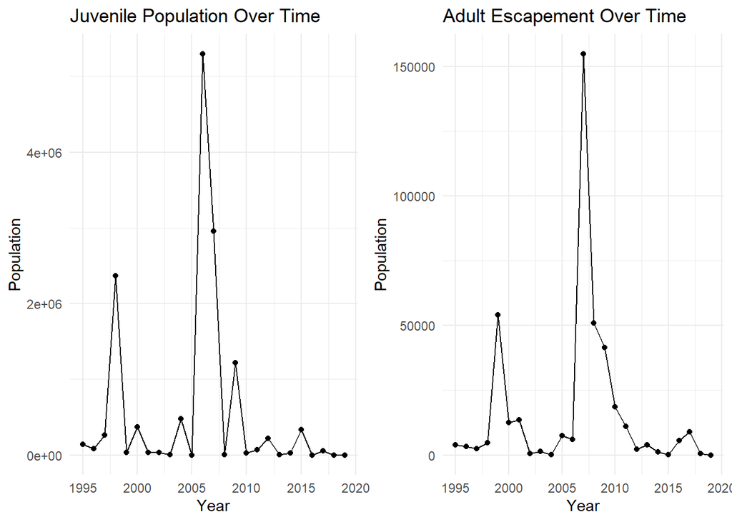

```r
# Initialize the population vectors
R_J = numeric(n_years)  # Juvenile population
R_A1 = numeric(n_years)  # Adults returning after 1 year
R_A2 = numeric(n_years)  # Adults returning after 2 years
R_A = numeric(n_years)  # Total adult population
N_t = numeric(n_years)  # Total adults returning
E_t = numeric(n_years)  # Total escapement past CFD
C_t = numeric(n_years)  # Harvest
B_t = numeric(n_years)  # Brood stock removal
H_t = numeric(n_years)  # Hatchery-origin spawners
alpha = t(matrix(3,1,n_years)) #Juvenile production rate

# Initial values
R_J[1:3] = exp(rnorm(3, log(118729), sigma_RJ0))  # Mean 118,729, SD 87,881
R_A1[1:3] = exp(rnorm(3, log(2500), sigma_RA0))  # Rough approximation
R_A2[1:3] = exp(rnorm(3, log(2500), sigma_RA0))  # Rough approximation
R_A[1:3] = R_A1[1:3] + R_A2[1:3]  # Total adults

N_t[1:3] = R_A[1:3]  # Initial adult returns

C_t[1:3] = N_t[1:3]*harvest_rate # Initial harvest
B_t[1:3] = N_t[1:3] *bsr  # Initial brood stock removal
H_t[1:3] = N_t[1:3] *hos # Initial hatchery-origin spawner
E_t[1:3] =  N_t[1:3] - C_t[1:3] - B_t[1:3]- H_t[1:3] # Initial total escapement

# Simulate the life cycle
for (y in 3:(n_years-2)) {

  #Juvenile production rate, dependent on FCE and Spill
  alpha[y] = exp(theta_0 + theta_1 * FCE[y] + theta_2 * Sp[y])

  # Juvenile production
  R_J[y+1] = exp(log(E_t[y]) + log(alpha[y]) - beta * E_t[y]+ rnorm(1, 0, sigma_pJ))

  # Total returning adults from juveniles (fixed JAR)
  R_A_total = exp(log(R_J[y]) + log(JAR) + rnorm(1, 0, sigma_pA))

  # Sample return proportions from Dirichlet distribution
  p_A_y = rdirichlet(1, gamma_A)  # Returns a 1-row matrix

  # Assign proportions
  p_A1_y = p_A_y[1]  # Proportion of 1-year returners
  p_A2_y = p_A_y[2]  # Proportion of 2-year returners

  # Allocate adults into return classes
  R_A1[y+1] = p_A1_y * R_A_total  # 1-year returners
  R_A2[y+2] = p_A2_y * R_A_total  # 2-year returners (delayed by 2 years)

  # Total adults in year y+1
  R_A[y+1] = R_A1[y+1] + R_A2[y+1]  # Note: R_A2[y+1] is from previous years

  N_t[y+1] = R_A[y+1]

  # Harvest and escapement calculations
  C_t[y+1]= harvest_rate * N_t[y+1]
  B_t[y+1]= bsr * N_t[y+1]  # Assume 5% taken for brood stock
  H_t[y+1]= hos * N_t[y+1]  # Assume 10% hatchery origin

  # Total escapement past CFD
  E_t[y+1]= N_t[y+1] - C_t[y+1] - B_t[y+1] + H_t[y+1]
}

years = 1995:(1995 + n_years - 1)
df_obs = data.frame(Year = years, Juveniles = R_J, Adults = E_t)

library(gridExtra)
p1 = ggplot(df_obs, aes(x = Year, y = Juveniles)) +
  geom_point() +
  geom_line() +
  labs(title = "Juvenile Population Over Time", x = "Year", y = "Population") +
  theme_minimal()

p2 = ggplot(df_obs, aes(x = Year, y = Adults)) +
  geom_point() +
  geom_line() +
  labs(title = "Adult Escapement Over Time", x = "Year", y = "Population") +
  theme_minimal()

grid.arrange(p1, p2, nrow = 1)
```

## Initial impressions.

# The full State Space Model

## Data Preparation

Log-transform the observed juvenile and adult counts to stabilize variance and ensure normality.

```r
log_RA1 = log(R_A1+1)
log_RA2 = log(R_A2+1)
log_RJ = log(R_J+1)
log_RA = log(R_A1+R_A2+1)
Y = cbind(log_RA1, log_RA2, log_RJ, log_RA)  # Combine into a matrix
```

## Define the Stan Model

The model describes the process and observation components: - **Process model:** Defines the latent state dynamics of juvenile and adult recruits. - **Observation model:** Links observed data to latent states, incorporating observation error.

```r
stan_code1 = "
data {
  int<lower=1> n_years;       // Number of years
  vector[n_years] FCE;      // Fish collection efficiency
  vector[n_years] Sp;       // Spill days
  matrix[n_years, 4] Y;       // Log-transformed observed recruits
}

parameters {
  real theta_0;
  real theta_1;
  real theta_2;
  real<lower=0> beta;
  real<lower=0> JAR;
  real<lower=0> sigma_pJ;
  real<lower=0> sigma_pA1;
  real<lower=0> sigma_pA2;
  real<lower=0> a1;
  real<lower=0> a2;
  vector[n_years] log_RJ;
  vector[n_years] log_RA1;
  vector[n_years] log_RA2;
}

model {
  // Priors
  theta_0 ~ normal(0, 5);
  theta_1 ~ normal(0, 5);
  theta_2 ~ normal(0, 5);
  beta ~ normal(0, 0.01);
  a1 ~ normal(0, 5);
  a2 ~ normal(0, 5);
  JAR ~ uniform(0, 1);
  sigma_pJ ~ normal(0, 1);
  sigma_pA1 ~ normal(0, 1);
  sigma_pA2 ~ normal(0, 1);

  // Process model
  for (y in 3:(n_years-2)) {

    //Juvenile production rate, dependent on FCE and Spill
    real alpha_y = exp(theta_0 + theta_1 * FCE[y] + theta_2 * Sp[y]);
    // Juvenile production
    log_RJ[y+1] ~ normal(log(exp(log_RA1[y])+exp(log_RA2[y]))+ log(alpha_y) - beta * (exp(log_RA1[y])+exp(log_RA2[y])),  sigma_pJ);

    // Total returning adults from juveniles (fixed JAR)
    log_RA1[y+1] ~ normal (a1*(log_RJ[y] + log(JAR)), sigma_pA1);
    log_RA2[y+2] ~ normal (a2*(log_RJ[y] + log(JAR)), sigma_pA2);
  }

  // Observation model
  for (y in 1:n_years) {
    Y[y, 1] ~ normal(log_RA1[y], sigma_pA1);
    Y[y, 2] ~ normal(log_RA2[y], sigma_pA2);
    Y[y, 3] ~ normal(log_RJ[y], sigma_pJ);
    //Y[y, 4] ~ normal(log_RA[y], sigma_pA);

  }
}
"
```

### Explanation of Stan Code

**Parameters Block**: Specifies model parameters, including population productivity (theta_0), environmental effects (theta_1, theta_2), density dependence (beta), and transition rates (JAR). Process errors (sigma_pJ, sigma_pA) account for biological variation.

**Model Block**: - The process model describes the true dynamics of juvenile and adult recruitment. - The observation model links observed data to the latent states, incorporating measurement uncertainty.

## Model Fitting

Prepare the data and run the model. Running the fit can take some time.

```r
stan_data = list(
  n_years = n_years,
  FCE = FCE,
  Sp = Sp,
  Y = Y
)

fit1 = stan(model_code = stan_code1, data = stan_data, iter = 2000, chains = 4, cores = 4)

#Get the posterior samples and predictions for analysis
posterior_samples1 = extract(fit1)
log_RJ_pred1 = apply(posterior_samples1$log_RJ, 2, median)
log_RA1_pred1 = apply(posterior_samples1$log_RA1, 2, median)
log_RA2_pred1 = apply(posterior_samples1$log_RA2, 2, median)
```

# Model Diagnostics and Results

## Plots of actual vs. predicted populations

It’s always nice to plot the predictions made by the fitted model against the actual data. This will give us our first visual indication of whether we’ve captured the underlying dynamics.

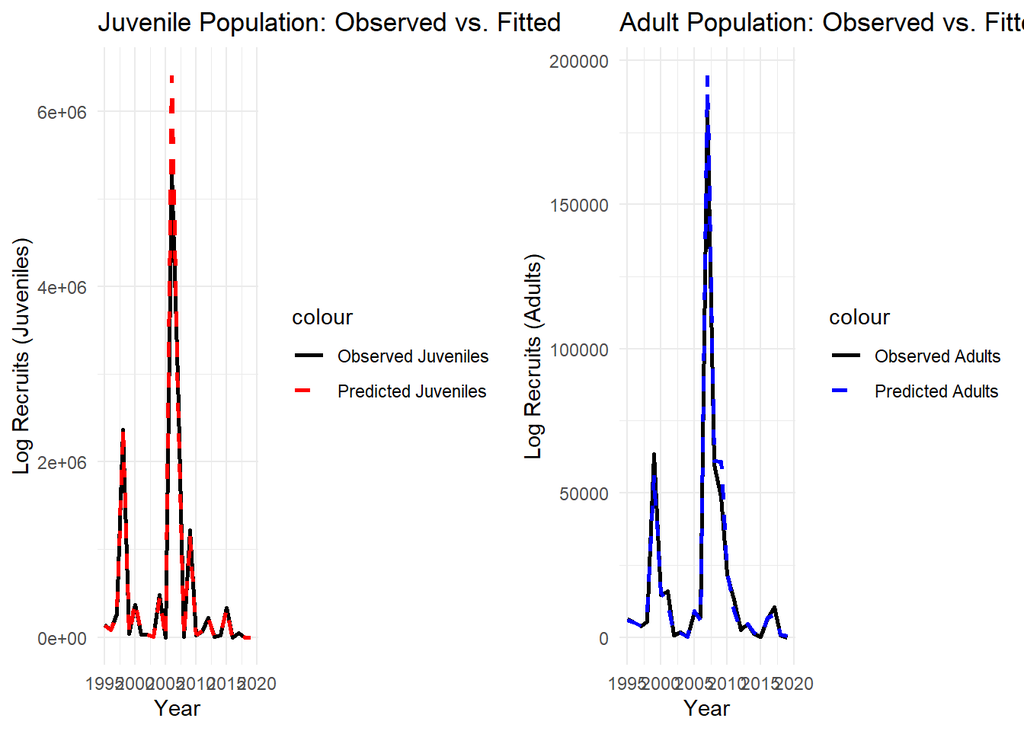

```r
# Create a dataframe for plotting
plot_data <- data.frame(
  Year = years,
  Observed_J = (R_J),
  Observed_A = (R_A),
  Predicted_J = exp(log_RJ_pred1),
  Predicted_A = exp(log_RA1_pred1)+exp(log_RA2_pred1)
)

# Plot Juvenile predictions vs. observed
p1 = ggplot(plot_data, aes(x = Year)) +
  geom_line(aes(y = Observed_J, color = "Observed Juveniles"), size = 1) +
  geom_line(aes(y = Predicted_J, color = "Predicted Juveniles"), size = 1, linetype = "dashed") +
  labs(title = "Juvenile Population: Observed vs. Fitted",
       y = "Log Recruits (Juveniles)", x = "Year") +
  scale_color_manual(values = c("Observed Juveniles" = "black", "Predicted Juveniles" = "red")) +
  theme_minimal()

# Plot Adult predictions vs. observed
p2 = ggplot(plot_data, aes(x = Year)) +
  geom_line(aes(y = Observed_A, color = "Observed Adults"), size = 1) +
  geom_line(aes(y = Predicted_A, color = "Predicted Adults"), size = 1, linetype = "dashed") +
  labs(title = "Adult Population: Observed vs. Fitted",
       y = "Log Recruits (Adults)", x = "Year") +
  scale_color_manual(values = c("Observed Adults" = "black", "Predicted Adults" = "blue")) +
  theme_minimal()

grid.arrange(p1, p2, nrow = 1)
```

## Simulated vs. Estimated Parameters

```r
params1 = data.frame(
  Parameter = c("theta_0", "theta_1", "theta_2", "beta", "JAR", "a1", "a2"),
  Simulated = c(log(theta_0), theta_1, theta_2, beta, JAR, gamma_A/sum(gamma_A)),
  Estimated = c(median(posterior_samples1$theta_0), median(posterior_samples1$theta_1),
                median(posterior_samples1$theta_2), median(posterior_samples1$beta),
                median(posterior_samples1$JAR),median(posterior_samples1$a1),median(posterior_samples1$a2))
)

knitr::kable(params1)
```

| Parameter | Simulated | Estimated |
| --- | --- | --- |
| theta_0 | 1.5445427 | 3.8272686 |
| theta_1 | 3.5010000 | 4.2112695 |
| theta_2 | -0.3000000 | -0.2918009 |
| beta | 0.0000680 | 0.0000526 |
| JAR | 0.0360000 | 0.0224418 |
| a1 | 0.6666667 | 0.9994624 |
| a2 | 0.3333333 | 0.8548169 |

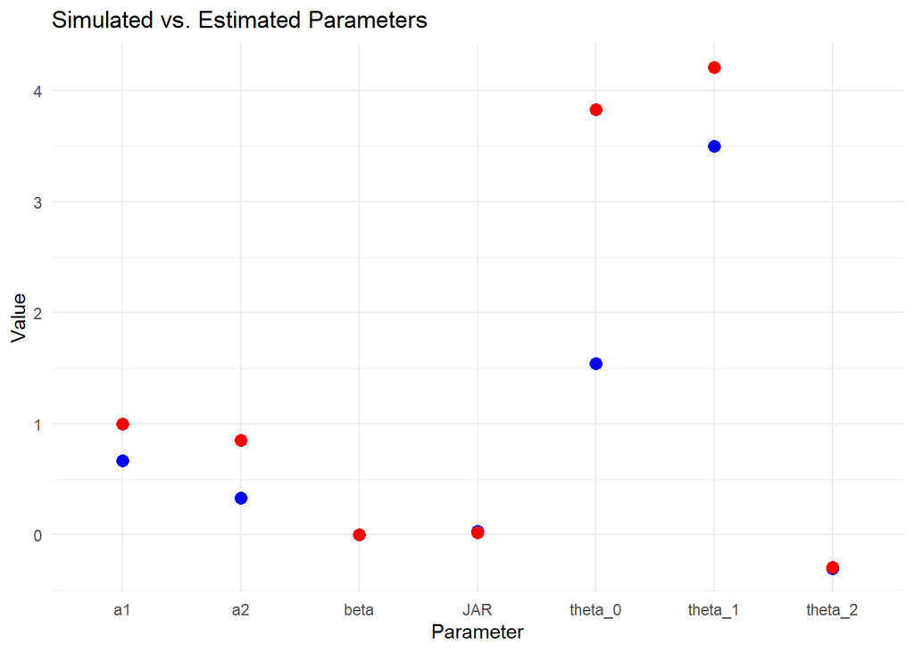

```r
ggplot(params1, aes(x = Parameter, y = Simulated)) +
  geom_point(color = "blue", size = 3) +
  geom_point(aes(y = Estimated), color = "red", size = 3) +
  geom_line(aes(y = Simulated, group = Parameter), color = "blue", linetype = "dashed") +
  geom_line(aes(y = Estimated, group = Parameter), color = "red") +
  labs(title = "Simulated vs. Estimated Parameters", y = "Value") +
  theme_minimal()
```

## Observed vs. Predicted Values

Plot the predicted vs. actual values, plot the 1-to-1 line, and see how well points match to this line.

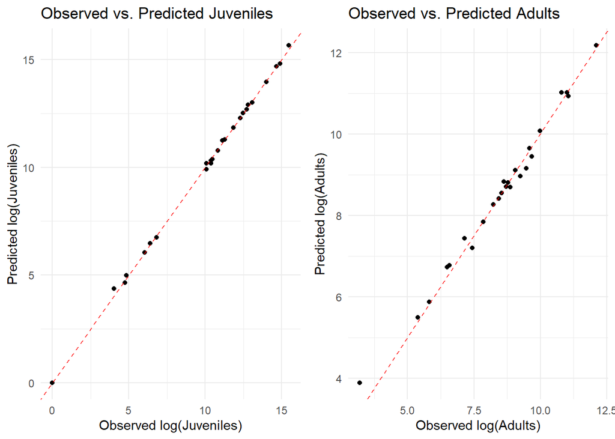

```r
df_obs_pred1 = data.frame(
  Year = years,
  Observed_J = Y[, 3],
  Predicted_J = log_RJ_pred1,
  Observed_A = Y[, 4],
  Predicted_A = log(exp(log_RA1_pred1)+exp(log_RA2_pred1))
)

p1=ggplot(df_obs_pred1, aes(x = Observed_J, y = Predicted_J)) +
  geom_point() +
  geom_abline(slope = 1, intercept = 0, linetype = "dashed", color = "red") +
  labs(title = "Observed vs. Predicted Juveniles", x = "Observed log(Juveniles)", y = "Predicted log(Juveniles)") +
  theme_minimal()

p2=ggplot(df_obs_pred1, aes(x = Observed_A, y = Predicted_A)) +
  geom_point() +
  geom_abline(slope = 1, intercept = 0, linetype = "dashed", color = "red") +
  labs(title = "Observed vs. Predicted Adults", x = "Observed log(Adults)", y = "Predicted log(Adults)") +
  theme_minimal()

grid.arrange(p1, p2, nrow = 1)
```

## Residual Analysis

Look at the residuals and visually inspect their dispersion. Any remaining clustering or trends would be indicative of sources of variation that we have not accounted for.

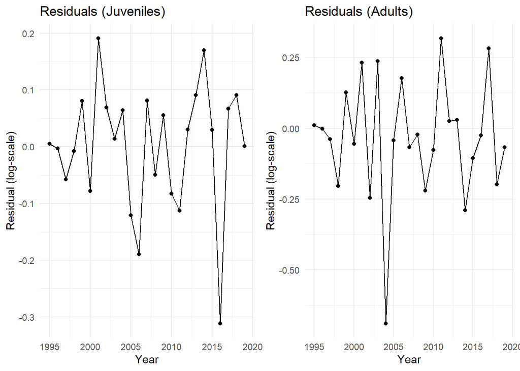

```r
df_residuals1 = data.frame(
  Year = years,
  Residual_J = Y[, 3] - log_RJ_pred1,
  Residual_A = Y[, 4] - log(exp(log_RA1_pred1)+exp(log_RA2_pred1))
)

p1 = ggplot(df_residuals1, aes(x = Year, y = Residual_J)) +
  geom_line() + geom_point() +
  labs(title = "Residuals (Juveniles)", x = "Year", y = "Residual (log-scale)") +
  theme_minimal()

p2 = ggplot(df_residuals1, aes(x = Year, y = Residual_A)) +
  geom_line() + geom_point() +
  labs(title = "Residuals (Adults)", x = "Year", y = "Residual (log-scale)") +
  theme_minimal()

grid.arrange(p1, p2, nrow = 1)
```

# Multiple model comparison

When working with models at this level of complexity, that incorporate dynamic, non-linear, multi-stage processes, it can be quite daunting to think about how to determine what the “best” model is. A time-consuming but reliable way to explore how uncertainty is resolved by different models is to sequentially fit the different models, and then compare them in terms of their ability to predict observed data. We have already developed different versions of the SSM, defined in Stan, and fit them. Now we can compare them against each other.

One of the most effective metrics for comparing different model fits is the Root-Mean-Square Error (RMSE), which measures the distance between predicted and observed values. It reflects the average distance that predicted values are from the actual values. The formula for RMSE is

$$RMSE = \sqrt{\frac{1}{n} \sum_{i=1}^{n} (y_i - \hat{y}_i)^2}$$

### Why is RMSE Useful for Comparing State-Space Models?

**Measures Overall Prediction Error** RMSE quantifies how well a state-space model predicts observed data, considering both bias (systematic error) and variance (random fluctuations).

**Penalizes Large Errors More Heavily** Since RMSE squares the errors before averaging, larger discrepancies between predictions and observations contribute more to the final value. This is useful in state-space models where extreme deviations can indicate poor model performance.

**Comparability Across Models** When fitting different state-space models (e.g., with different process noise structures, observation models, or priors), RMSE provides a single metric to compare their predictive accuracy.

**Interpretability in Original Units** Unlike other error metrics such as Mean Absolute Error (MAE), RMSE retains the same units as the observed data, making it easier to interpret in practical terms.

## New model version

The second version of the SSM attempts to capture the variability in the return rates of the two different adult cohorts, coded into the population dynamics via the Dirichlet distribution $\gamma_i$.

```r
stan_code2 = "
data {
  int<lower=1> n_years;       // Number of years
  vector[n_years] FCE;      // Fish collection efficiency
  vector[n_years] Sp;       // Spill days
  matrix[n_years, 4] Y;       // Log-transformed observed recruits
  vector[2] gamma_A;          // Dirichlet hyperparameters
}

parameters {
  real theta_0;
  real theta_1;
  real theta_2;
  real<lower=0> beta;
  real<lower=0, upper=1> JAR;
  real<lower=0> sigma_pJ;
  real<lower=0> sigma_pA;
  vector[n_years] log_RJ;
  vector[n_years] log_RA1;
  vector[n_years] log_RA2;
  simplex[2] p_A_y[n_years];  // Dirichlet-distributed return proportions
}

model {
  // Priors
  theta_0 ~ normal(0, 5);
  theta_1 ~ normal(0, 5);
  theta_2 ~ normal(0, 5);
  beta ~ normal(0, 0.01);
  JAR ~ uniform(0, 1);
  sigma_pJ ~ normal(0, 1);
  sigma_pA ~ normal(0, 1);

  // Dirichlet prior on return proportions
  for (y in 1:n_years) {
    p_A_y[y] ~ dirichlet(gamma_A);
  }


  // Process model
  for (y in 3:(n_years-2)) {

    // Juvenile production rate
    real alpha_y = exp(theta_0 + theta_1 * FCE[y] + theta_2 * Sp[y]);

    // Juvenile production
    log_RJ[y+1] ~ normal(log(exp(log_RA1[y]) + exp(log_RA2[y])) + log(alpha_y) - beta * (exp(log_RA1[y]) + exp(log_RA2[y])), sigma_pJ);

    // Total returning adults from juveniles
    real log_RA_total = log_RJ[y] + log(JAR);

    // Allocate returners based on Dirichlet proportions
    log_RA1[y+1] ~ normal(log_RA_total + log(p_A_y[y, 1]), sigma_pA);
    log_RA2[y+2] ~ normal(log_RA_total + log(p_A_y[y, 2]), sigma_pA);
  }


  // Observation model
  for (y in 1:n_years) {
    Y[y, 1] ~ normal(log_RA1[y], sigma_pA);
    Y[y, 2] ~ normal(log_RA2[y], sigma_pA);
    Y[y, 3] ~ normal(log_RJ[y], sigma_pJ);
  }
}
"
```

## Model Fitting

Prepare the data and run the model. Running the fit can take some time.

```r
stan_data = list(
  n_years = n_years,
  FCE = FCE,
  Sp = Sp,
  Y = Y,
  gamma_A = c(2, 1)  # Make sure this is included as a vector of length 2

)

fit2 = stan(model_code = stan_code2, data = stan_data, iter = 2000, chains = 4, cores = 4)

#Get the posterior samples and predictions for analysis
posterior_samples2 = extract(fit2)
log_RJ_pred2 = apply(posterior_samples2$log_RJ, 2, median)
log_RA1_pred2 = apply(posterior_samples2$log_RA1, 2, median)
log_RA2_pred2 = apply(posterior_samples2$log_RA2, 2, median)
```

Calculate RMSE for the two fits:

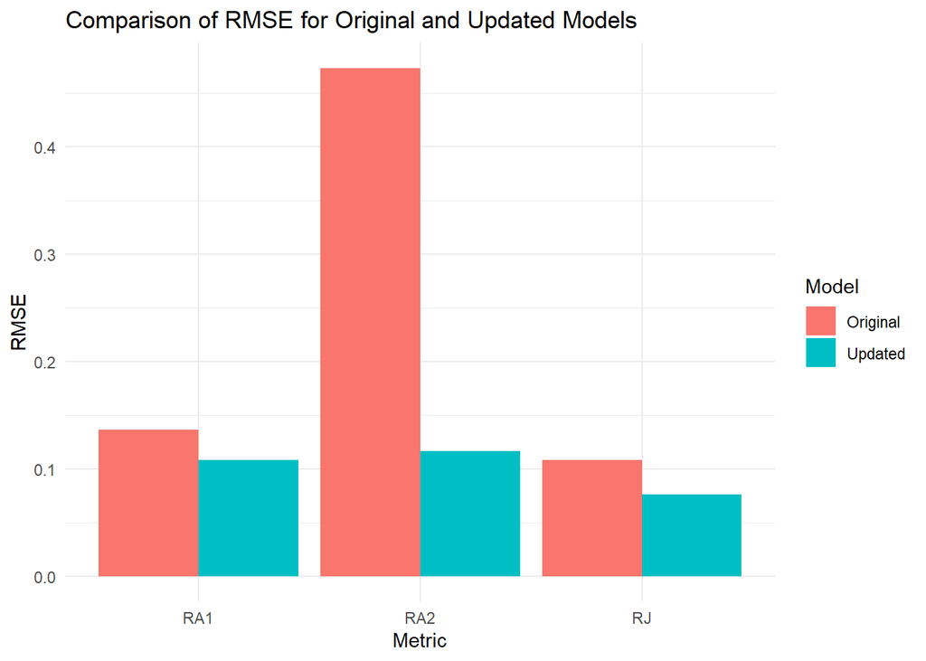

```r
# Compute RMSE for fit 1
rmse_RJ_m1 <- sqrt(mean((Y[,3] - log_RJ_pred1)^2))
rmse_RA1_m1 <- sqrt(mean((Y[,1] - log_RA1_pred1)^2))
rmse_RA2_m1 <- sqrt(mean((Y[,2] - log_RA2_pred1)^2))
rmse_mod1 = c(RJ = rmse_RJ_m1, RA1 = rmse_RA1_m1, RA2 = rmse_RA2_m1)

# Compute RMSE for fit 2
rmse_RJ_m2 <- sqrt(mean((Y[,3] - log_RJ_pred2)^2))
rmse_RA1_m2 <- sqrt(mean((Y[,1] - log_RA1_pred2)^2))
rmse_RA2_m2 <- sqrt(mean((Y[,2] - log_RA2_pred2)^2))
rmse_mod2 = c(RJ = rmse_RJ_m2, RA1 = rmse_RA1_m2, RA2 = rmse_RA2_m2)

# Create a DataFrame for plotting
rmse_df <- data.frame(
  Model = rep(c("Original", "Updated"), each = 3),
  Metric = rep(c("RJ", "RA1", "RA2"), times = 2),
  RMSE = c(rmse_mod1, rmse_mod2)
)

# Plot RMSE comparison
ggplot(rmse_df, aes(x = Metric, y = RMSE, fill = Model)) +
  geom_bar(stat = "identity", position = "dodge") +
  theme_minimal() +
  labs(title = "Comparison of RMSE for Original and Updated Models",
       y = "RMSE",
       x = "Metric")
```

We can see from this figure that the updated model, model 2, performs better overall when looking at the RMSE

## Fitting and comparing simpler models

It may sometimes be the case that more complex models do not substantially improve RMSE. Expanding on the model comparison exercise, we can check to see how SSMs that are equivalent to our earlier, simpler models compare to the previous two models.

### Basic two stage model

This is the equivalent of the first model we looked at, the basic two-stage LCM.

```r
stan_code_A = "
data {
  int<lower=1> n_years;       // Number of years
  matrix[n_years, 2] Y;       // Log-transformed observed recruits
}

parameters {
  real<lower=0> alpha;
  real<lower=0> beta;
  real<lower=0> JAR;
  real<lower=0> sigma_pJ;
  real<lower=0> sigma_pA;
  vector[n_years] log_RJ;
  vector[n_years] log_RA;
}

model {
  // Uninformed priors
  alpha ~ uniform(0, 1);
  beta ~ uniform(0, 1);
  JAR ~ uniform(0, 1);
  sigma_pJ ~ exponential(1);
  sigma_pA ~ exponential(1);

  // Process model
  for (y in 2:(n_years-1)) {
    log_RJ[y+1] ~ normal(log_RA[y] + log(alpha) - beta * exp(log_RA[y]), sigma_pJ);
    log_RA[y+1] ~ normal(log_RJ[y] + log(JAR), sigma_pA);
  }

  // Observation model
  for (y in 1:n_years) {
    Y[y, 1] ~ normal(log_RJ[y], sigma_pJ);
    Y[y, 2] ~ normal(log_RA[y], sigma_pA);
  }
}
"
```

Then run the code:

```r
log_RA1 = log(R_A1+1)
log_RA2 = log(R_A2+1)
log_RJ = log(R_J+1)
log_RA = log(R_A1+R_A2+1)
Y_A = cbind(log_RJ, log_RA)  # Combine into a matrix

stan_data_A = list(
  n_years = n_years,
  Y = Y_A
)

fitA = stan(model_code = stan_code_A, data = stan_data_A, iter = 2000, chains = 4, cores = 4)

#Get the posterior samples and predictions for analysis
posterior_samplesA = extract(fitA)
log_RJ_predA = apply(posterior_samplesA$log_RJ, 2, median)
log_RA_predA = apply(posterior_samplesA$log_RA, 2, median)
```

### Two stage model with environmental covariates.

```r
stan_code_B = "
data {
  int<lower=1> n_years;       // Number of years
  vector[n_years] FCE;      // Fish collection efficiency
  vector[n_years] Sp;       // Spill days
  matrix[n_years, 2] Y;       // Log-transformed observed recruits
}

parameters {
  real theta_0;
  real theta_1;
  real theta_2;
  real<lower=0> beta;
  real<lower=0> JAR;
  real<lower=0> sigma_pJ;
  real<lower=0> sigma_pA;
  vector[n_years] log_RJ;
  vector[n_years] log_RA;
}

model {
  // Uninformed priors
  theta_0 ~ normal(0, 5);
  theta_1 ~ normal(0, 5);
  theta_2 ~ normal(0, 5);
  beta ~ uniform(0, 1);
  JAR ~ uniform(0, 1);
  sigma_pJ ~ exponential(1);
  sigma_pA ~ exponential(1);

  // Process model
  for (y in 2:(n_years-1)) {
    real alpha_y = exp(theta_0 + theta_1 * FCE[y] + theta_2 * Sp[y]);
    log_RJ[y+1] ~ normal(log_RA[y] + log(alpha_y) - beta * exp(log_RA[y]), sigma_pJ);
    log_RA[y+1] ~ normal(log_RJ[y] + log(JAR), sigma_pA);
  }

  // Observation model
  for (y in 1:n_years) {
    Y[y, 1] ~ normal(log_RJ[y], sigma_pJ);
    Y[y, 2] ~ normal(log_RA[y], sigma_pA);
  }
}
"
```

Now fit the model:

```r
log_RA1 = log(R_A1+1)
log_RA2 = log(R_A2+1)
log_RJ = log(R_J+1)
log_RA = log(R_A1+R_A2+1)
Y_B = cbind(log_RJ, log_RA)  # Combine into a matrix

stan_data_B = list(
  n_years = n_years,
  FCE = FCE,
  Sp = Sp,
  Y = Y_B
)

fitB = stan(model_code = stan_code_B, data = stan_data_B, iter = 2000, chains = 4, cores = 4)

#Get the posterior samples and predictions for analysis
posterior_samplesB = extract(fitB)
log_RJ_predB = apply(posterior_samplesB$log_RJ, 2, median)
log_RA_predB = apply(posterior_samplesB$log_RA, 2, median)
```

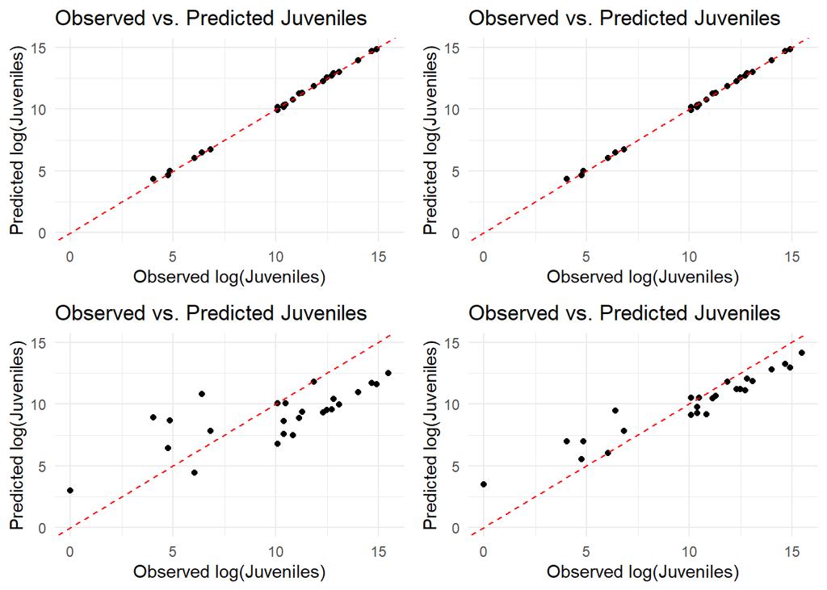

```r
df_obs_pred1 = data.frame(
  Year = years,
  Observed_J = Y[, 3],
  Predicted_J = log_RJ_pred1
)

df_obs_pred2 = data.frame(
  Year = years,
  Observed_J = Y[, 3],
  Predicted_J = log_RJ_pred2
)

df_obs_predA = data.frame(
  Year = years,
  Observed_J = Y_A[, 1],
  Predicted_J = log_RJ_predA
)

df_obs_predB = data.frame(
  Year = years,
  Observed_J = Y_B[, 1],
  Predicted_J = log_RJ_predB
)

p1=ggplot(df_obs_pred1, aes(x = Observed_J, y = Predicted_J)) +
  geom_point() +
  geom_abline(slope = 1, intercept = 0, linetype = "dashed", color = "red") +
  labs(title = "Observed vs. Predicted Juveniles", x = "Observed log(Juveniles)", y = "Predicted log(Juveniles)") +
  theme_minimal()+
  ylim(0, 15)  # Set y-axis limits

p2=ggplot(df_obs_pred1, aes(x = Observed_J, y = Predicted_J)) +
  geom_point() +
  geom_abline(slope = 1, intercept = 0, linetype = "dashed", color = "red") +
  labs(title = "Observed vs. Predicted Juveniles", x = "Observed log(Juveniles)", y = "Predicted log(Juveniles)") +
  theme_minimal()+
  ylim(0, 15)  # Set y-axis limits


p3=ggplot(df_obs_predA, aes(x = Observed_J, y = Predicted_J)) +
  geom_point() +
  geom_abline(slope = 1, intercept = 0, linetype = "dashed", color = "red") +
  labs(title = "Observed vs. Predicted Juveniles", x = "Observed log(Juveniles)", y = "Predicted log(Juveniles)") +
  theme_minimal()+
  ylim(0, 15)  # Set y-axis limits


p4=ggplot(df_obs_predB, aes(x = Observed_J, y = Predicted_J)) +
  geom_point() +
  geom_abline(slope = 1, intercept = 0, linetype = "dashed", color = "red") +
  labs(title = "Observed vs. Predicted Juveniles", x = "Observed log(Juveniles)", y = "Predicted log(Juveniles)") +
  theme_minimal()+
  ylim(0, 15)  # Set y-axis limits


grid.arrange(p1, p2, p3,p4, nrow = 2)
```

Calculate RMSE for all fits:

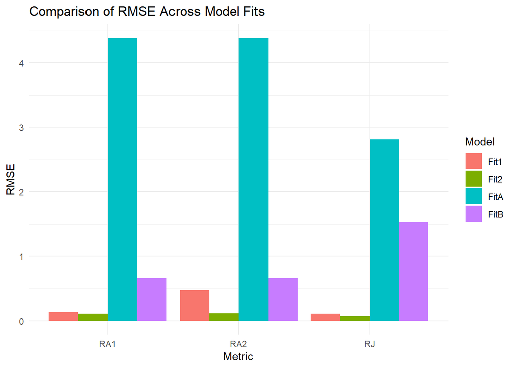

```r
# Compute RMSE for fit 1
rmse_RJ_m1 <- sqrt(mean((Y[,3] - log_RJ_pred1)^2))
rmse_RA1_m1 <- sqrt(mean((Y[,1] - log_RA1_pred1)^2))
rmse_RA2_m1 <- sqrt(mean((Y[,2] - log_RA2_pred1)^2))
rmse_mod1 = c(RJ = rmse_RJ_m1, RA1 = rmse_RA1_m1, RA2 = rmse_RA2_m1)

# Compute RMSE for fit 2
rmse_RJ_m2 <- sqrt(mean((Y[,3] - log_RJ_pred2)^2))
rmse_RA1_m2 <- sqrt(mean((Y[,1] - log_RA1_pred2)^2))
rmse_RA2_m2 <- sqrt(mean((Y[,2] - log_RA2_pred2)^2))
rmse_mod2 = c(RJ = rmse_RJ_m2, RA1 = rmse_RA1_m2, RA2 = rmse_RA2_m2)

# Compute RMSE for fit A
rmse_RJ_mA <- sqrt(mean((Y_A[,1] - log_RJ_predA)^2))
rmse_RA_mA <- sqrt(mean((Y[,2] - log_RA_predA)^2))
rmse_modA = c(RJ = rmse_RJ_mA, RA1 = rmse_RA_mA, RA2 = rmse_RA_mA )

# Compute RMSE for fit B
rmse_RJ_mB <- sqrt(mean((Y_B[,1] - log_RJ_predB)^2))
rmse_RA_mB <- sqrt(mean((Y_B[,2] - log_RA_predB)^2))
rmse_modB = c(RJ = rmse_RJ_mB, RA1 = rmse_RA_mB, RA2 = rmse_RA_mB )

# Create a DataFrame for plotting
rmse_df <- data.frame(
  Model = rep(c("Fit1", "Fit2", "FitA", "FitB"), each = 3),
  Metric = rep(c("RJ", "RA1", "RA2"), times = 4),
  RMSE = c(rmse_mod1, rmse_mod2, rmse_modA, rmse_modB)
)

# Plot RMSE comparison
ggplot(rmse_df, aes(x = Metric, y = RMSE, fill = Model)) +
  geom_bar(stat = "identity", position = "dodge") +
  theme_minimal() +
  labs(title = "Comparison of RMSE Across Model Fits",
       y = "RMSE",
       x = "Metric")
```

Not surprisingly in this case the SSM that most closely matches the actual dynamical model has the lowest RMSE. One of the biggest jumps in error reduction and uncertainty happens simply by connecting the adult productivity parameter to environmental covariates (FCE and Spill). Future explorations might involve modifying the simulation model to include more of the observed complexity. But it might also be just as useful to explore how different steps in adding complexity to the SSM influence the model fit, a comparison which can be made using RMSE.